# TP3- Grupo 3

Valeria Aguirre

## Introducción

### Encuesta Uso del tiempo 2016

Los datos elegidos son los de la encuesta sobre el uso del tiempo correspondiente al año 2016.

Es un relevamiento que realiza Dirección General de Estadística y Censos del Gobierno de la Ciudad de Buenos Aires. Tiene por objeto recoger información sobre el uso del tiempo que los habitantes de la Ciudad dedican a diferentes actividades incluyendo el trabajo remunerado, las actividades domésticas, el cuidado de niños, niñas, personas mayores o con discapacidad, el estudio, el esparcimiento, los viajes y traslados, etc. Se realizo a 4500 hogares a personas de la Ciudad Autónoma de Buenos Aires de 14 años y más.

Para mayor información sobre la encuesta consultar el [documento metodógico](https://www.estadisticaciudad.gob.ar/eyc/wp-content/uploads/2017/10/UT_CABA_2017.pdf) o la [base usuaia](https://www.estadisticaciudad.gob.ar/eyc/?p=74110).

## Exploración de los datos

Carga de base

```r
encuesta_uso_tiempo_2016 <- read.csv("Datos/encuesta_uso_tiempo_2016.csv", header = TRUE)
```

Dimensiones

```r
dim(encuesta_uso_tiempo_2016)
```

```
## [1] 2336   27
```

Reconocimiento de variables

```r
names(encuesta_uso_tiempo_2016)
```

```
##  [1] "hogar"                      "sexo"
##  [3] "edad"                       "dia_laborable"
##  [5] "trabajo_pago"               "trabajo_domestico_no_pago"
##  [7] "voluntariados"              "estudio_educacion"
##  [9] "recreacion"                 "aplicaciones"
## [11] "tareas_cuidados"            "cuidado_personal"
## [13] "trabajo_pago2"              "trabajo_domestico_no_pago2"
## [15] "voluntariados2"             "estudio_educacion2"
## [17] "recreacion2"                "aplicaciones2"
## [19] "tareas_cuidados2"           "cuidado_personal2"
## [21] "dia_tipico"                 "rango_etario"
## [23] "nivel_educativo"            "relacion_parentesco_jefe"
## [25] "tipo_hogar"                 "quintil_ingreso"
## [27] "estado_ocupacional"
```

Tipo de variables

```r
summary(encuesta_uso_tiempo_2016)
```

```
##     hogar               sexo                edad       dia_laborable
##  Length:2336        Length:2336        Min.   :14.00   Length:2336
##  Class :character   Class :character   1st Qu.:31.00   Class :character
##  Mode  :character   Mode  :character   Median :46.00   Mode  :character
##                                        Mean   :47.79
##                                        3rd Qu.:63.00
##                                        Max.   :97.00
##   trabajo_pago   trabajo_domestico_no_pago voluntariados     estudio_educacion
##  Min.   : 0.00   Min.   : 0.000            Min.   : 0.0000   Min.   : 0.0000
##  1st Qu.: 0.00   1st Qu.: 0.600            1st Qu.: 0.0000   1st Qu.: 0.0000
##  Median : 0.50   Median : 1.900            Median : 0.0000   Median : 0.0000
##  Mean   : 4.24   Mean   : 2.575            Mean   : 0.4082   Mean   : 0.7343
##  3rd Qu.: 8.80   3rd Qu.: 3.800            3rd Qu.: 0.0000   3rd Qu.: 0.0000
##  Max.   :22.50   Max.   :15.700            Max.   :24.0000   Max.   :16.8000
##    recreacion      aplicaciones    tareas_cuidados  cuidado_personal
##  Min.   : 0.000   Min.   : 0.000   Min.   : 0.000   Min.   : 1.50
##  1st Qu.: 1.000   1st Qu.: 0.300   1st Qu.: 0.000   1st Qu.: 9.80
##  Median : 2.800   Median : 1.500   Median : 0.000   Median :11.30
##  Mean   : 3.549   Mean   : 2.132   Mean   : 1.175   Mean   :11.68
##  3rd Qu.: 5.000   3rd Qu.: 3.000   3rd Qu.: 0.000   3rd Qu.:13.20
##  Max.   :32.500   Max.   :14.300   Max.   :19.300   Max.   :25.70
##  trabajo_pago2    trabajo_domestico_no_pago2 voluntariados2
##  Min.   : 0.000   Min.   : 0.000             Min.   : 0.0000
##  1st Qu.: 0.000   1st Qu.: 0.500             1st Qu.: 0.0000
##  Median : 0.500   Median : 1.700             Median : 0.0000
##  Mean   : 4.188   Mean   : 2.266             Mean   : 0.3216
##  3rd Qu.: 8.700   3rd Qu.: 3.300             3rd Qu.: 0.0000
##  Max.   :22.500   Max.   :12.800             Max.   :13.5000
##  estudio_educacion2  recreacion2     aplicaciones2    tareas_cuidados2
##  Min.   : 0.0000    Min.   : 0.000   Min.   : 0.000   Min.   : 0.0000
##  1st Qu.: 0.0000    1st Qu.: 0.500   1st Qu.: 0.300   1st Qu.: 0.0000
##  Median : 0.0000    Median : 2.000   Median : 1.500   Median : 0.0000
##  Mean   : 0.7234    Mean   : 2.662   Mean   : 2.121   Mean   : 0.8038
##  3rd Qu.: 0.0000    3rd Qu.: 3.900   3rd Qu.: 3.000   3rd Qu.: 0.0000
##  Max.   :16.5000    Max.   :15.900   Max.   :14.300   Max.   :13.2000
##  cuidado_personal2  dia_tipico        rango_etario       nivel_educativo
##  Min.   : 1.00     Length:2336        Length:2336        Length:2336
##  1st Qu.: 9.20     Class :character   Class :character   Class :character
##  Median :10.60     Mode  :character   Mode  :character   Mode  :character
##  Mean   :10.96
##  3rd Qu.:12.40
##  Max.   :23.40
##  relacion_parentesco_jefe  tipo_hogar        quintil_ingreso
##  Length:2336              Length:2336        Length:2336
##  Class :character         Class :character   Class :character
##  Mode  :character         Mode  :character   Mode  :character
##
##
##
##  estado_ocupacional
##  Length:2336
##  Class :character
##  Mode  :character
##
##
##
```

La base de datos de referencia consta de 27 variables y 2336 observaciones. La encuesta da cuenta del uso del tiempo con y sin simultaneidad. Por tal motivo, 8 variables de la base tienen el mismo nombre. En este caso, del listado de variables vamos a considerar para analizar son las variables “sexo”, “rango etario”, “trabajo_domestico_no_pago2”, “tareas_cuidado2” y “trabajo_pago2”. Estas últimas dan cuenta del tiempo sin simultaneidad.

## Tablas estadísticas

#### **Población total según sexo**

```r
encuesta_uso_tiempo_2016 %>%
group_by(sexo) %>%
  summarise(n=n()) %>%
  mutate(porcentaje = n/sum(n)*100) %>%
  knitr::kable(col.names = c("Sexo", "Total", "Porcentajes"))
```

| Sexo | Total | Porcentajes |
| --- | --- | --- |
| Mujer | 1345 | 57.57705 |
| Varon | 991 | 42.42295 |

#### **Trabajo pago según sexo**

```r
encuesta_uso_tiempo_2016 %>%
select(sexo, trabajo_pago2) %>%
  group_by(sexo) %>%
  filter(trabajo_pago2 > 0) %>%
  summarise(Promedio = mean(trabajo_pago2),
            DesvStandard = sd(trabajo_pago2),
            Valor_minimo = min(trabajo_pago2),
            Valor_maximo = max(trabajo_pago2),
            n = n ()) %>%
  mutate(porcentaje = n/sum(n)*100) %>%
  knitr::kable(col.names = c("Sexo", "Promedio hs", "Desvío estandar", "Valor mínimo", "Valor  máximo","Total casos", "Porcentaje"))
```

| Sexo | Promedio hs | Desvío estandar | Valor mínimo | Valor máximo | Total casos | Porcentaje |
| --- | --- | --- | --- | --- | --- | --- |
| Mujer | 7.879281 | 3.090538 | 0.5 | 18.5 | 584 | 49.74446 |
| Varon | 8.781864 | 3.172124 | 0.2 | 22.5 | 590 | 50.25554 |

```r
#Se excluyeron los valores "0"
```

Del total de casos de la base (2336), solo 1174 informó haber trabajado de manera remunerada, del cual el 49,7% son mujeres y el 50,3 varones.

Observando el promedio de horas trabajadas por sexo, vemos que los varones dedican más tiempo diario al trabajo remunerado que las mujeres. Siendo la media de los varones 8,7hs y la de las mujeres 7,8hs diarias.

En el caso del trabajo remunerado el rango en las mujeres es de 0,5hs hasta 18,5hs, y para los varones es de 0,2hs a 22.5hs.

Tanto en mujeres como en varones el desvío estandar es alto, alcanzando las 3hs.

#### **Trabajo doméstico no pago según sexo**

```r
encuesta_uso_tiempo_2016 %>%
  select(sexo, trabajo_domestico_no_pago2) %>%
  group_by(sexo) %>%
  filter(trabajo_domestico_no_pago2 > 0) %>%
  summarise(Promedio = mean(trabajo_domestico_no_pago2),
            DesvStandard = sd(trabajo_domestico_no_pago2),
            Valor_minimo = min(trabajo_domestico_no_pago2),
            Valor_maximo = max(trabajo_domestico_no_pago2),
            n = n ()) %>%
  mutate(porcentaje = n/sum(n)*100) %>%
  knitr::kable(col.names = c("Sexo", "Promedio", "Desvío estandar", "Valor mínimo", "Valor  máximo","Total casos", "Porcentaje"))
```

| Sexo | Promedio | Desvío estandar | Valor mínimo | Valor máximo | Total casos | Porcentaje |
| --- | --- | --- | --- | --- | --- | --- |
| Mujer | 2.978398 | 2.312755 | 0.1 | 12.8 | 1236 | 59.48027 |
| Varon | 1.914727 | 1.781994 | 0.1 | 11.8 | 842 | 40.51973 |

```r
#Se excluyeron los valores "0"
```

Del total de casos de la base, 2078 personas informaron dedicar tiempo diaria al trabajo doméstico, siendo el 59,5% mujeres y el 40,5 varones.

Según se observa en la tabla,las mujeres dedican en promedio mayor tiempo diario al trabajo domestico que los varones. La media de las mujeres es de 2,9hs, mientras que la media de los varones es de 1,9hs.

En el caso de las mujeres los valores para la variable “trabajo doméstico no pago” van desde 0,1hs hasta 12,8hs. Mientras que el rango de los varones es de 0,1hs a 11,8hs.

El desvío estandar para las mujeres es de 2,3 hs y el de los varones de 1,7hs.

#### **Tareas del cuidado según sexo**

```r
encuesta_uso_tiempo_2016 %>%
  select(sexo, tareas_cuidados2) %>%
  group_by(sexo) %>%
  filter(tareas_cuidados2 > 0) %>%
  summarise(Promedio = mean(tareas_cuidados2),
            DesvStandard = sd(tareas_cuidados2),
            Valor_minimo = min(tareas_cuidados2),
            Valor_maximo = max(tareas_cuidados2),
            n = n ()) %>%
  mutate(porcentaje = n/sum(n)*100) %>%
  knitr::kable(col.names = c("Sexo", "Promedio", "Desvío estandar", "Valor mínimo", "Valor  máximo","Total casos", "Porcentaje"))
```

| Sexo | Promedio | Desvío estandar | Valor mínimo | Valor máximo | Total casos | Porcentaje |
| --- | --- | --- | --- | --- | --- | --- |
| Mujer | 3.977208 | 2.753801 | 0.1 | 12.8 | 351 | 65.60748 |
| Varon | 2.617935 | 2.064282 | 0.1 | 13.2 | 184 | 34.39252 |

```r
#Se excluyeron los valores "0"
```

Respecto de las tareas del cuidado, se observa que solo 535 personas informaron realizar estas actividades, de las cuales el 65,6% fueron mujeres y el 34,4% varones.

Las mujeres le dedican más tiempo diario a estas tareas en comparación con los varones (3,9hs vs 2,6hs). En ambos casos el desvío standar es alto, 2,7 hs para las mujeres y 2hs los varones.

## Hipótesis

Existe una relación desigual en la distribución del uso del tiempo entre varones y mujeres, la cual se puede observar al ver el tipo de trabajo (Trabajo pago y trabajo doméstico no pago). Siendo las mujeres quienes dedican mayor tiempo diario a las tareas domésticas, mientras que los varones dedican mayor tiempo al trabajo productivo. Esto puede verse justificado a partir de la división sexual del trabajo y los roles de géneros de las sociedades modernas.

Pero ¿como se dan esas diferencias según grupos etarios? ¿que particularidades se pueden observar al tomar en consideración el trabajo no pago del cuidado a miembros del hogar? ¿Existe una sobrecarga de trabajo para las mujeres aún cuando también realizan tareas laborales remuneradas?

Nuestra hipótesis sostiene que al contraponer el tiempo de “trabajo productivo” (trabajo pago) con el “trabajo reproductivo/no remunerado” (trabajo domestico y del cuidado de miembros del hogar), resultan ser las mujeres quienes dedican más horas de su día al trabajo que los varones. Implicando una sobrecarga de trabajo invisibilizada.

## Visualizaciones

```r
#Tablas frecuencias filtradas (NA) segun tipo de trabajo (para unificar)

frecuencia_trab_pago <- encuesta_uso_tiempo_2016 %>%
  select(hogar, sexo, trabajo_pago2) %>%
  filter(trabajo_pago2 > 0)

frecuencia_trab_domestico <- encuesta_uso_tiempo_2016 %>%
  select(hogar, sexo, trabajo_domestico_no_pago2) %>%
  filter(trabajo_domestico_no_pago2 > 0)

frecuencia_tareas_cuidados <- encuesta_uso_tiempo_2016 %>%
  select(hogar, sexo, tareas_cuidados2) %>%
  filter(tareas_cuidados2 > 0)

#Unificar tablas (FULL_JOIN)

trabajo_mix <- full_join(frecuencia_trab_pago, frecuencia_trab_domestico)

trabajo_mix_ <- full_join(trabajo_mix, frecuencia_tareas_cuidados)
```

#### **Tipo de trabajo según sexo**

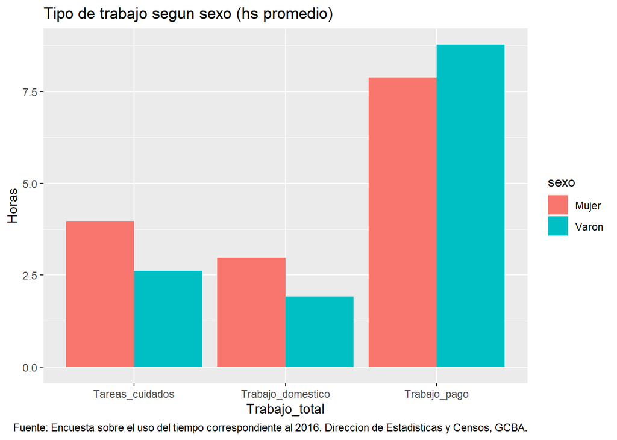

```r
trabajo_mix_ %>%
  group_by(sexo) %>%
  summarise(Trabajo_pago = mean(trabajo_pago2, na.rm = TRUE),
            Trabajo_domestico = mean(trabajo_domestico_no_pago2, na.rm = TRUE),
            Tareas_cuidados = mean(tareas_cuidados2, na.rm = TRUE)) %>%
  pivot_longer(cols = Trabajo_pago:Tareas_cuidados,
               names_to="Trabajo_total",
               values_to="Horas") %>%
  ggplot(aes(Trabajo_total, Horas)) +
  geom_col(aes(fill=sexo),
           position="dodge") +
  labs(title = "Tipo de trabajo segun sexo (hs promedio)",
       caption = "Fuente: Encuesta sobre el uso del tiempo correspondiente al 2016. Direccion de Estadisticas y Censos, GCBA.")
```

```r
#Se excluyeron los valores "0" (NA)
```

Al diferenciar el trabajo pago del trabajo no remunerado, se observa que es mayor la cantidad de horas diarias promedio que le dedican los varones al trabajo pago que el que le dedican las mujeres.

Por otra parte, al considerar las tareas del cuidado y el trabajo doméstico, se observa que la brecha entre varones y mujeres en cuanto a la distribución del tiempo se invierte, siendo las mujeres quienes más tiempo diario le dedican a estas tareas.

#### **Trabajo pago segun sexo**

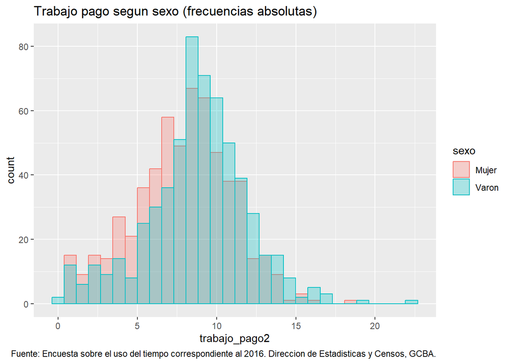

```r
#histograma trabajo pago segun sexo
encuesta_uso_tiempo_2016 %>%
  filter(trabajo_pago2 > 0) %>%
  ggplot(aes(trabajo_pago2, fill=sexo, color=sexo)) +
  geom_histogram(alpha=0.3, position = 'identity') +
  labs(title = "Trabajo pago segun sexo (frecuencias absolutas)",
  caption = "Fuente: Encuesta sobre el uso del tiempo correspondiente al 2016. Direccion de Estadisticas y Censos, GCBA.")
```

Según se observa en el gráfico, el tiempo destinado al trabajo pago con mayor frecuencia es entre 7-12hs diarias. Al ver las frecuencias según sexo, se nota una mayor dedicación de horas por los varones y una menor dedicación de las mujeres.

#### **Trabajo doméstico segun sexo**

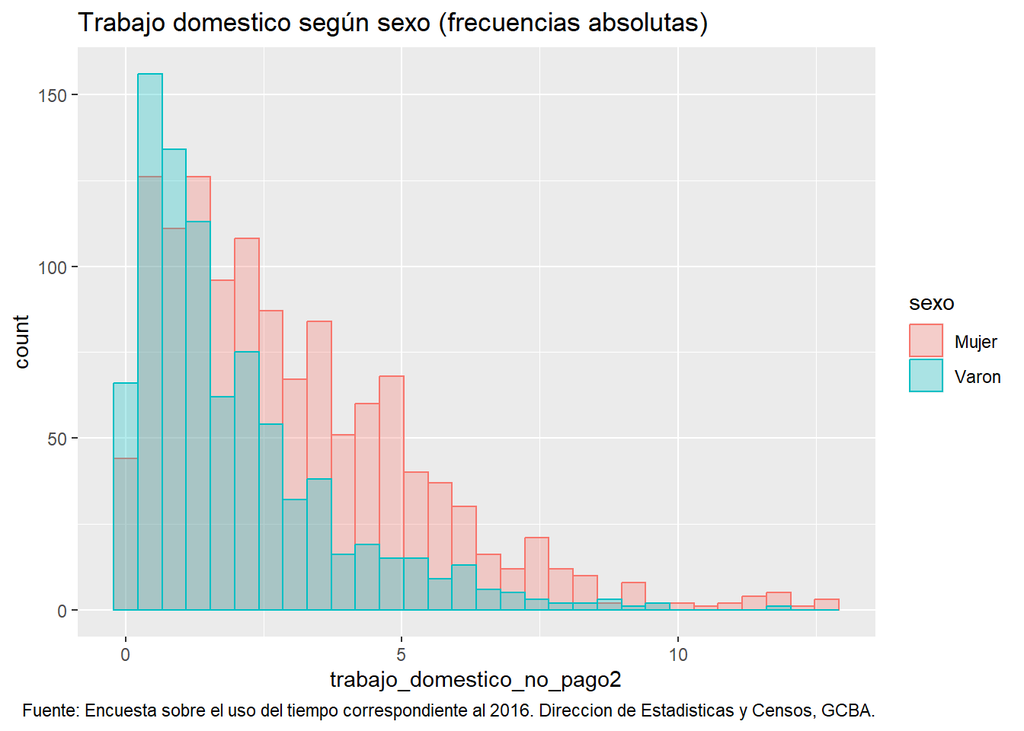

```r
#histograma trabajo domestico no pago segun sexo
encuesta_uso_tiempo_2016 %>%
  filter(trabajo_domestico_no_pago2 > 0) %>%
  ggplot(aes(trabajo_domestico_no_pago2, fill=sexo, color=sexo)) +
  geom_histogram(alpha=0.3, position = 'identity') +
  labs(title = "Trabajo domestico según sexo (frecuencias absolutas)",
  caption = "Fuente: Encuesta sobre el uso del tiempo correspondiente al 2016. Direccion de Estadisticas y Censos, GCBA.")
```

Respecto del trabajo domestico no pago, es mayor la dedicación horaria de las mujeres, sinendo los varones quienes menos horas le dedican a estas tareas.

#### **Tareas del cuidado según sexo**

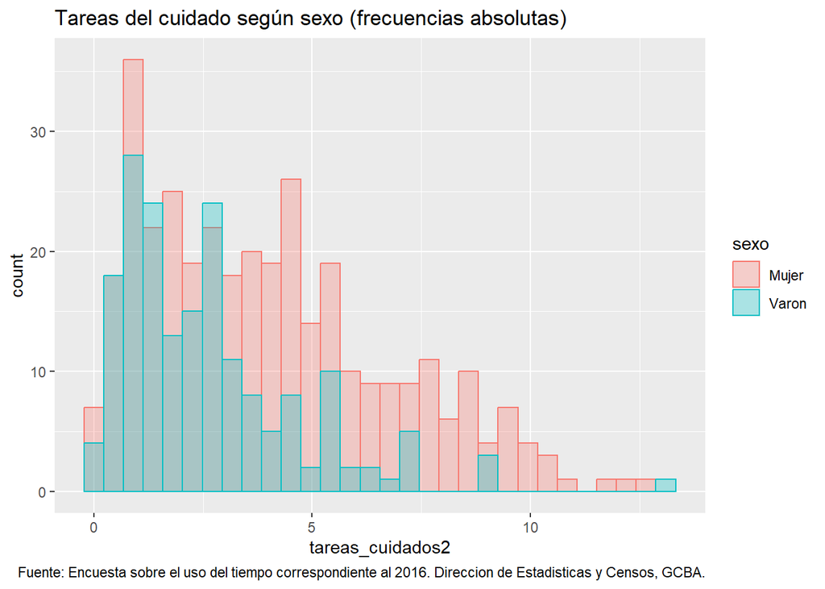

```r
#histograma tareas del cuidado segun sexo
encuesta_uso_tiempo_2016 %>%
  filter(tareas_cuidados2 > 0) %>%
  ggplot(aes(tareas_cuidados2, fill=sexo, color=sexo)) +
  geom_histogram(alpha=0.3, position = 'identity') +
  labs(title = "Tareas del cuidado según sexo (frecuencias absolutas)",
  caption = "Fuente: Encuesta sobre el uso del tiempo correspondiente al 2016. Direccion de Estadisticas y Censos, GCBA.")
```

En el caso de las tareas del cuidado, se observan que es baja la frecuencia general. Y al igual que con el trabajo doméstico, los varones dedican menos tiempo diario a realizar tareas del cuidado.

#### **Trabajo pago segun edad y sexo**

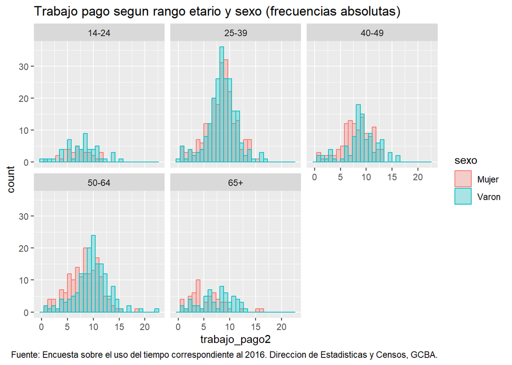

```r
#histograma frecuencia trabajo pago según rango etario y sexo
encuesta_uso_tiempo_2016 %>%
  filter(trabajo_pago2 > 0) %>%
  ggplot(aes(trabajo_pago2, fill=sexo, color=sexo)) +
  geom_histogram(alpha=0.3, position = 'identity') +
  facet_wrap(~rango_etario) +
  labs(title = "Trabajo pago segun rango etario y sexo (frecuencias absolutas)",
  caption = "Fuente: Encuesta sobre el uso del tiempo correspondiente al 2016. Direccion de Estadisticas y Censos, GCBA.")
```

Según se observa en el gráfico histograma de frecuencias del trabajo pago según grupo etario, el periodo de mayor dedicación de tiempo se observa entre los 25 y 64 años de edad. Siendo el rango 14-24 y 65+ los de menor frecuencia. Para el rango de 25-39 años no se observan diferencias significativas de didicación por sexo. En cambio, para el rango de edad de 40-64 años se distingue una menor dedicación de tiempo de las mujeres al trabajo pago.

#### **Trabajo doméstico segun edad y sexo**

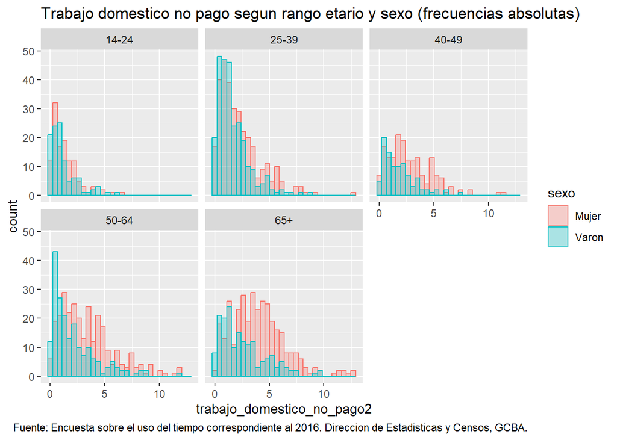

```r
#histograma frecuencia trabajo domestico no pago segùn rango etario y sexo
encuesta_uso_tiempo_2016 %>%
  filter(trabajo_domestico_no_pago2 > 0) %>%
  ggplot(aes(trabajo_domestico_no_pago2, fill=sexo, color=sexo)) +
  geom_histogram(alpha=0.3, position = 'identity') +
  facet_wrap(~rango_etario) +
  labs(title = "Trabajo domestico no pago segun rango etario y sexo (frecuencias absolutas)",
       caption = "Fuente: Encuesta sobre el uso del tiempo correspondiente al 2016. Direccion de Estadisticas y Censos, GCBA.")
```

#### Tareas de cuidados segun edad y sexo

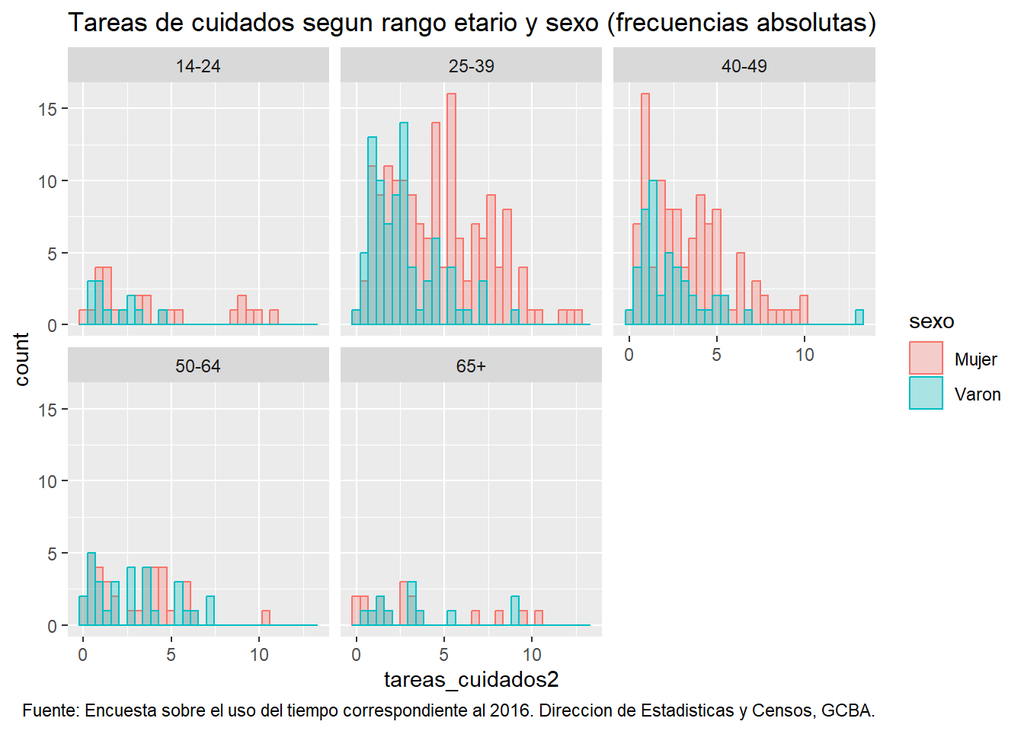

```r
#histograma frecuencia tareas de cuidados según rango etario y sexo
encuesta_uso_tiempo_2016 %>%
  filter(tareas_cuidados2 > 0) %>%
  ggplot(aes(tareas_cuidados2, fill=sexo, color=sexo)) +
  geom_histogram(alpha=0.3, position = 'identity') +
  facet_wrap(~rango_etario) +
  labs(title = "Tareas de cuidados segun rango etario y sexo (frecuencias absolutas)",
       caption = "Fuente: Encuesta sobre el uso del tiempo correspondiente al 2016. Direccion de Estadisticas y Censos, GCBA.")
```

## Conclusiones

Nuestra hipotesis original planteaba que existía una relación desigual en la distribución del uso del tiempo entre varones y mujeres, donde al tomar en cuenta el tipo de trabajo (pago/no pago), era mayor el tiempo diario de trabajo de las mujeres en comparación a los varones.

A partir del análisis de los datos, vimos que el uso del tiempo se distribuye de manera diferente según sexo y rango etarios. Siendo el tiempo promedio dedicado al trabajo pago mayor para los varones que para las mujeres, y en el caso del trabajo no remunerado del hogar (tareas domesticas y del cuidado) es mayor el tiempo promedio de las mujeres que los varones.

Al tomar en consideración la edad, pudimos ver que no se distribuye de manera homogenea el uso del tiempo según sexo en cada tipo de trabajo, sino que asumen particularidades.

De manera que emerge del análisis la necesidad de tomar en cuenta la simultaneidad de tareas de trabajo, para poder medir, más alla de la cantidad de horas de trabajo, la “intensidad”.